# Machine Learning course Assignment

December 15, 2014

**INTRODUCTION**

The goal of this project was to predict the quality of a physical activity given a set of predictors.

**Data pre-processing**

First I loaded the data into R and checked the dimensions and data structure

```r
Train<-read.csv(file="~/Documents/machinelearning/data/pml-training.csv", header=TRUE)
Test<-read.csv(file="~/Documents/machinelearning/data/pml-testing.csv", header=TRUE)

dim(Train)
```

```
## [1] 19622   160
```

```r
dim(Test)
```

```
## [1]  20 160
```

Once data was introduced I started with a series of procedures to filter the data. First I extracted the first 7 data columns, which only contains accessory information. Following this filter I selected only the numerical columhns and took out the columns with a large number of NAs.

```r
strain<-Train[,-c(1:7)]
strain[strain==""]<-NA
strain[strain=="#DIV/0!"]<-NA

x <- sapply(strain, is.numeric)
str<-strain[ ,c(x)]

str$classe<-strain$classe
str<-str[,colSums(is.na(str)) < 19000]
```

After these first filters I divided the original dataset in training and testing.

```r
library(caret)
training <- createDataPartition(y = str$classe, p = 0.7, list = FALSE)
trData <- str[training, ]
testVData <- str[-training, ]

dim(testVData)
```

```
## [1] 5885   53
```

```r
dim(trData)
```

```
## [1] 13737    53
```

Then in the training dataset I looked for correlated variables.

```r
M<-abs(cor(trData[,-53]))
diag(M)=0
which(M>0.8,arr.ind=T)
```

```
##                  row col
## yaw_belt           3   1
## total_accel_belt   4   1
## accel_belt_y       9   1
## accel_belt_z      10   1
## accel_belt_x       8   2
## magnet_belt_x     11   2
## roll_belt          1   3
## roll_belt          1   4
## accel_belt_y       9   4
## accel_belt_z      10   4
## pitch_belt         2   8
## magnet_belt_x     11   8
## roll_belt          1   9
## total_accel_belt   4   9
## accel_belt_z      10   9
## roll_belt          1  10
## total_accel_belt   4  10
## accel_belt_y       9  10
## pitch_belt         2  11
## accel_belt_x       8  11
## gyros_arm_y       19  18
## gyros_arm_x       18  19
## magnet_arm_x      24  21
## accel_arm_x       21  24
## magnet_arm_z      26  25
## magnet_arm_y      25  26
## accel_dumbbell_x  34  28
## accel_dumbbell_z  36  29
## pitch_dumbbell    28  34
## yaw_dumbbell      29  36
```

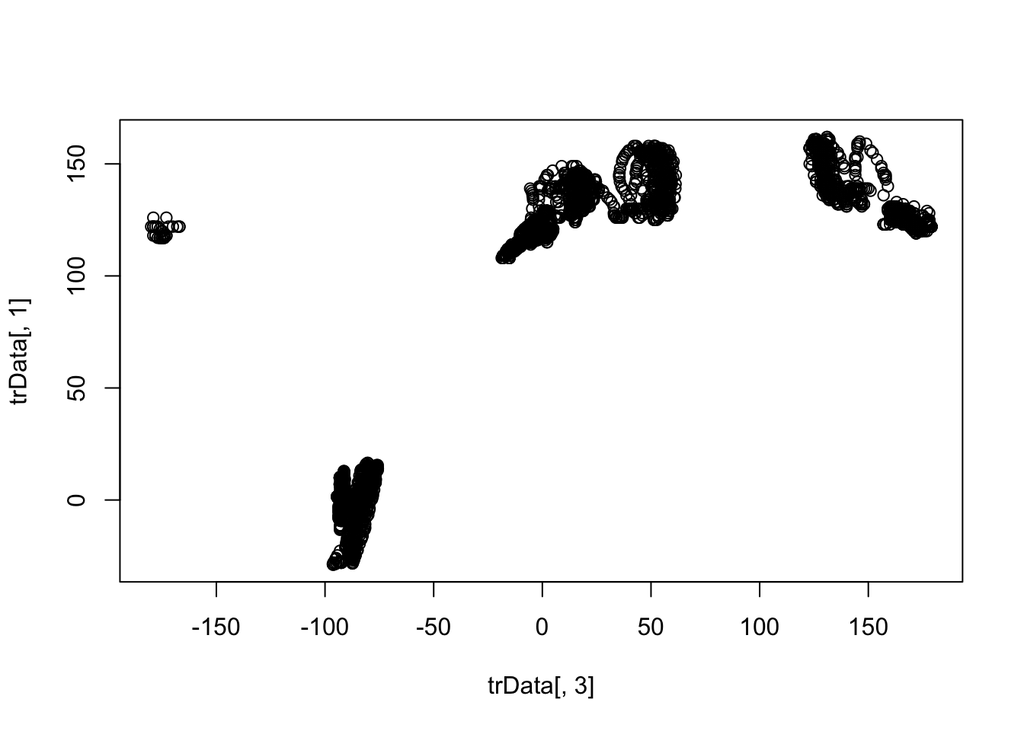

```r
plot(trData[,3],trData[,1])
```

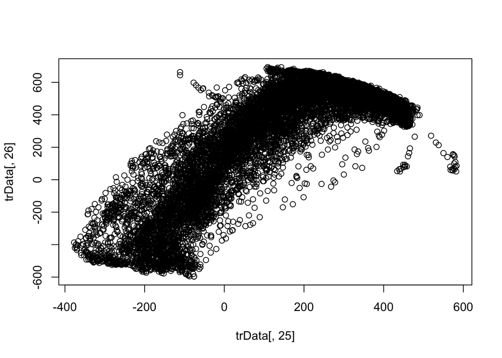

```r
plot(trData[,25],trData[,26])
```

I eliminated the most correlated variables, and subset both test datasets (the one I made and the original one) to the final variables used to build the model.

```r
trData<-trData[,-c(1,2,9,8,10,11,18,21,26,31,33,34,36,46)]

n<-names(trData)
stest<-Test[,which(names(Test) %in% n)]
testVData<-testVData[,which(names(testVData) %in% n)]
```

**Modelling procedures**

To obtain a realiable model I used a random forest, with the algorithm implemented in the Caret package. I created a Training control parameter to limit the Cross-Validation to 3. When doing the tests I also tested a CV of 4 folds, however the accuracy improvement was minimum. Using a smaller k value will influenciate in the out-of-sample error values, obtaining a less precise estimate, but reducing the variance. Like this using a 3-fold CV I can overcome a potential overfitting error, with a small out of sample error value.

```r
control1 <- trainControl(method = "cv", number = 3, allowParallel = TRUE)

modFit<-train(classe~., data=trData, method="rf",trControl = control1, prox=FALSE)
```

After building the model I used the tested data I build in order to have a better estimate of the out-of-sample error.

```r
predictions <- predict(modFit, testVData)

outOfSampleError.accuracy <- sum(predictions == testVData$classe)/length(predictions)
outOfSampleError.accuracy
```

```
## [1] 0.9935429
```

```r
outOfSampleError <- 1 - outOfSampleError.accuracy
```

Finally I applied the model to the given test dataset and build the text files to submit the result.

```r
pred<-predict(modFit,stest)

pml_write_files = function(x){
  n = length(x)
  for(i in 1:n){
    filename = paste0("problem_id_",i,".txt")
    write.table(x[i],file=filename,quote=FALSE,row.names=FALSE,col.names=FALSE)
  }
}
setwd("~/Documents/machinelearning")

pml_write_files(pred)
```

**Results**

Model results showed high accuracy value using a 3 fold CV. The low value of the OOB error (out-of-sample error) reinforces the good performance of the model.

```r
print(modFit)
```

```
## Random Forest
##
## 13737 samples
##    38 predictor
##     5 classes: 'A', 'B', 'C', 'D', 'E'
##
## No pre-processing
## Resampling: Cross-Validated (3 fold)
##
## Summary of sample sizes: 9157, 9159, 9158
##
## Resampling results across tuning parameters:
##
##   mtry  Accuracy  Kappa  Accuracy SD  Kappa SD
##    2    0.987     0.983  0.00194      0.00245
##   20    0.988     0.984  0.00183      0.00232
##   38    0.980     0.975  0.00420      0.00532
##
## Accuracy was used to select the optimal model using  the largest value.
## The final value used for the model was mtry = 20.
```

```r
modFit$finalModel
```

```
##
## Call:
##  randomForest(x = x, y = y, mtry = param$mtry, proximity = FALSE)
##                Type of random forest: classification
##                      Number of trees: 500
## No. of variables tried at each split: 20
##
##         OOB estimate of  error rate: 0.85%
## Confusion matrix:
##      A    B    C    D    E class.error
## A 3900    4    2    0    0 0.001536098
## B   24 2624    9    0    1 0.012791573
## C    0   22 2362   12    0 0.014190317
## D    2    0   25 2222    3 0.013321492
## E    0    0    5    8 2512 0.005148515
```

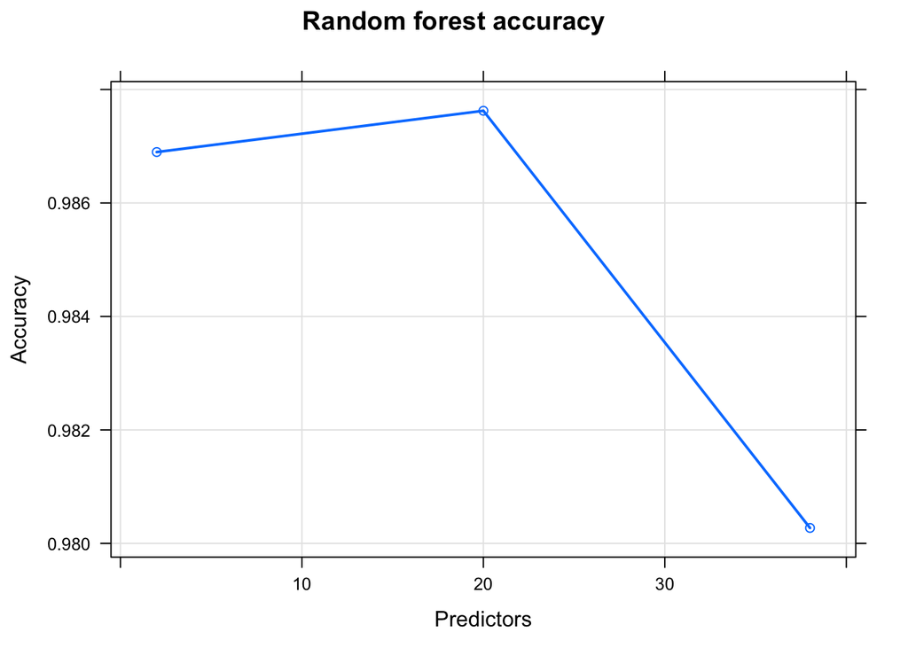

```r
plot(modFit, log = "y", lwd = 2, main = "Random forest accuracy", xlab = "Predictors", ylab = "Accuracy")
```

The results of the prediction were:

```r
pred
```

```
##  [1] B A B A A E D B A A B C B A E E A B B B
## Levels: A B C D E
```

The out of samples error using an external test dataset was:

```r
outOfSampleError * 100
```

```
## [1] 0.6457094
```